# Filogenética con R

Profesor: R Computación

```r
virus <- c("PP747613", "PP434597", "2688674532", "PP747674", "PP693357","BS010617", "PP584656", "OR841414", "OZ029930", "PP754055", "PP126626", "OY723591", "OY290355", "PP425353", "PP565348", "OP302810", "OR427989", "PP294547", "OR726214", "ON564872")
```

1. Carga las librerías necesarias:

```r
if (!require("BiocManager", quietly = TRUE))
    install.packages("BiocManager")


library(Biostrings)
library(seqinr)
```

```r
library(ggplot2)

library(adegenet)
library(ape)
library(ggtree)
library(DECIPHER)
library(viridis)
```

2. Obtén las secuencias:

```r
virus_sequences <- read.GenBank(virus)
```

3. Estructura del DNABin:

```r
str(virus_sequences)
```

```
## List of 20
##  $ PP747613  : raw [1:29649] 88 48 88 18 ...
##  $ PP434597  : raw [1:29903] 88 18 18 88 ...
##  $ 2688674532: raw [1:29828] 88 18 18 88 ...
##  $ PP747674  : raw [1:29742] 48 88 18 28 ...
##  $ PP693357  : raw [1:29409] 88 18 48 48 ...
##  $ BS010617  : raw [1:29783] 88 48 88 18 ...
##  $ PP584656  : raw [1:29744] 28 88 88 48 ...
##  $ OR841414  : raw [1:29803] 18 18 48 18 ...
##  $ OZ029930  : raw [1:29890] f0 f0 f0 f0 ...
##  $ PP754055  : raw [1:29702] 28 18 28 18 ...
##  $ PP126626  : raw [1:29814] 88 88 88 48 ...
##  $ OY723591  : raw [1:29777] 18 18 48 18 ...
##  $ OY290355  : raw [1:29848] f0 f0 f0 f0 ...
##  $ PP425353  : raw [1:29748] 28 18 18 48 ...
##  $ PP565348  : raw [1:3810] 88 18 48 18 ...
##  $ OP302810  : raw [1:29701] 18 28 18 28 ...
##  $ OR427989  : raw [1:29871] 18 88 88 88 ...
##  $ PP294547  : raw [1:29582] 48 48 28 18 ...
##  $ OR726214  : raw [1:29792] 88 88 28 88 ...
##  $ ON564872  : raw [1:3728] 28 28 88 28 ...
##  - attr(*, "class")= chr "DNAbin"
##  - attr(*, "description")= chr [1:20] "PP747613.1 Severe acute respiratory syndrome coronavirus 2 isolate SARS-CoV-2/human/USA/2024CV0721/2024 ORF1ab "| __truncated__ "PP434597.1 Severe acute respiratory syndrome coronavirus 2 isolate SARS-CoV-2/human/IND/MP-GMC_B-IND-G19/2023, complete genome" "…
##  - attr(*, "species")= chr [1:20] "Severe_acute_respiratory_syndrome_coronavirus_2" "Severe_acute_respiratory_syndrome_coronavirus_2" "Severe_acute_respiratory_syndrome_coronavirus_2" "Severe_acute_respiratory_syndrome_coronavirus_2" ...
```

```r
attributes(virus_sequences)
```

```
## $names
##  [1] "PP747613"   "PP434597"   "2688674532" "PP747674"   "PP693357"
##  [6] "BS010617"   "PP584656"   "OR841414"   "OZ029930"   "PP754055"
## [11] "PP126626"   "OY723591"   "OY290355"   "PP425353"   "PP565348"
## [16] "OP302810"   "OR427989"   "PP294547"   "OR726214"   "ON564872"
##
## $class
## [1] "DNAbin"
##
## $description
##  [1] "PP747613.1 Severe acute respiratory syndrome coronavirus 2 isolate SARS-CoV-2/human/USA/2024CV0721/2024 ORF1ab polyprotein (ORF1ab), ORF1a polyprotein (ORF1ab), surface glycoprotein (S), ORF3a protein (ORF3a), envelope protein (E), membrane glycoprotein (M), ORF6 protein (ORF6), ORF7a prote…
##  [2] "PP434597.1 Severe acute respiratory syndrome coronavirus 2 isolate SARS-CoV-2/human/IND/MP-GMC_B-IND-G19/2023, complete genome"
##  [3] "PP405601.1 Severe acute respiratory syndrome coronavirus 2 isolate SARS-CoV-2/human/FRA/HEGP-81-10-2332993394i_p2/2022, complete genome"
##  [4] "PP747674.1 Severe acute respiratory syndrome coronavirus 2 isolate SARS-CoV-2/human/DEU/BY-USAFSAM-S22612/2024 ORF1ab polyprotein (ORF1ab), ORF1a polyprotein (ORF1ab), surface glycoprotein (S), ORF3a protein (ORF3a), envelope protein (E), membrane glycoprotein (M), ORF6 protein (ORF6), ORF7…
##  [5] "PP693357.1 Severe acute respiratory syndrome coronavirus 2 isolate SARS-CoV-2/human/BRA/RJ-LVM-62/2021, complete genome"
```

[output cut: 37 more lines]

```r
names(virus_sequences) <- c("USA", "India", "Francia", "Alemania", "Brasil", "Japon", "Corea_Sur", "Italia", "UK", "Rusia", "Turquia", "España", "Australia", "Vietnam", "Taiwan", "Argentina", "PB", "Mexico", "Iran", "Indonesia")
attr(virus_sequences, "species")
```

```
##  [1] "Severe_acute_respiratory_syndrome_coronavirus_2"
##  [2] "Severe_acute_respiratory_syndrome_coronavirus_2"
##  [3] "Severe_acute_respiratory_syndrome_coronavirus_2"
##  [4] "Severe_acute_respiratory_syndrome_coronavirus_2"
##  [5] "Severe_acute_respiratory_syndrome_coronavirus_2"
##  [6] "Severe_acute_respiratory_syndrome_coronavirus_2"
##  [7] "Severe_acute_respiratory_syndrome_coronavirus_2"
##  [8] "Severe_acute_respiratory_syndrome_coronavirus_2"
##  [9] "Severe_acute_respiratory_syndrome_coronavirus_2"
## [10] "Severe_acute_respiratory_syndrome_coronavirus_2"
## [11] "Severe_acute_respiratory_syndrome_coronavirus_2"
## [12] "Severe_acute_respiratory_syndrome_coronavirus_2"
## [13] "Severe_acute_respiratory_syndrome_coronavirus_2"
## [14] "Severe_acute_respiratory_syndrome_coronavirus_2"
## [15] "Severe_acute_respiratory_syndrome_coronavirus_2"
## [16] "Severe_acute_respiratory_syndrome_coronavirus_2"
## [17] "Severe_acute_respiratory_syndrome_coronavirus_2"
## [18] "Severe_acute_respiratory_syndrome_coronavirus_2"
## [19] "Severe_acute_respiratory_syndrome_coronavirus_2"
## [20] "Severe_acute_respiratory_syndrome_coronavirus_2"
```

4. Concentraremos en un archivo todas las secuencias:

```r
write.dna(virus_sequences,  file ="virus_seqs.fasta", format = "fasta", append =
FALSE, nbcol = 6, colsep = " ", colw = 10)
```

5. Cargamos la secuencias:

```r
virus_seq_no_alineadas <- readDNAStringSet("virus_seqs.fasta", format = "fasta")
virus_seq_no_alineadas
```

```
## DNAStringSet object of length 20:
##      width seq                                              names
##  [1] 29649 AGATCTGTTCTCTAAACGAACTT...AAAGAGCCACCACATTTTCACC USA
##  [2] 29903 ATTAAAGGTTTATACCTTCCCAG...AAAAAAAAAAAAAAAAAAAAAA India
##  [3] 29828 ATTAAAGGTTTATACCTTCCCAG...AGGAGAATGACAAAAAAAAAAA Francia
##  [4] 29742 GATCTGTTCTCTAAACGAACTTT...ATTTTAATAGCTTCTTAGGAGA Alemania
##  [5] 29409 ATGGAGAGCCTTGTCCCTGGTTT...AGTTAACTTTAATCTCACATAG Brasil
##  ...   ... ...
## [16] 29701 TCTCTAAACGAACTTTAAAATCT...GTACGATCGAGTGTACAGTGAA Argentina
## [17] 29871 TAAAGGTTTATACCTTCCTAGGT...AAAAAAAAAAAAAAAAAAAAAA PB
## [18] 29582 GGCTGTCACTCGGCTGCATGCTT...TTTAATCTCACATAGCAATCTT Mexico
## [19] 29792 AACAAACCAACCAACTTTCGATC...CCTAATGTGTAAAATTAATTTT Iran
## [20]  3728 CCACTAGTCTCTAGTCAGTGTGT...TCAAGGGCTGTTGTTCTTGTGG Indonesia
```

6. Alineamiento de las secuencias: Un alineamiento múltiple de secuencias es un alineamiento de más de dos secuencias. Estas secuencias, como en el caso de los alieamientos por parejas pueden ser ADN, ARN o proteína. Las aplicaciones más habituales de los alineamientos múltiples son:
- la reconstrucción filogenética,
- el análisis estructural de proteínas,
- la búsqueda de dominios conservados y
- la búsqueda de regiones conservadas en promotores. En todos los casos los algoritmos de alineamiento múltiple asumen que las secuencias que estamos alineando descienden de un antepasado común y lo que intentamos hacer es alinear las posiciones homólogas.

[figure not shown]

```r
virus_seq_no_alineadas <- OrientNucleotides(virus_seq_no_alineadas)
```

```
## ========================================================================================================================
##
## Time difference of 0.08 secs
```

```r
virus_align_seqs <- AlignSeqs(virus_seq_no_alineadas)
```

[output not shown]

7. Visualizar el resultado del alineamiento:

```r
BrowseSeqs(virus_align_seqs, highlight=0)
```

8. Guardar el resultado:

```r
writeXStringSet(virus_align_seqs, file = "virus_align_seq.fasta")
```

9. Obtener el nuevo archivo:

```r
virus_aligned <- read.alignment("virus_align_seq.fasta", format = "fasta")
```

10. Crear una matriz de distancia:

```r
matriz_distancia <- dist.alignment(virus_aligned, matrix = "similarity")
```

11. Visualiza la matriz de distancia: donde sombras más oscuras de gris significan una mayor distancia

```r
temp <- as.data.frame(as.matrix(matriz_distancia))
temp
```

```
##                  USA      India    Francia   Alemania     Brasil      Japon
## USA       0.00000000 0.06520309 0.05227877 0.02661950 0.06978117 0.02012143
## India     0.06520309 0.00000000 0.05613734 0.06430837 0.03641599 0.06295810
## Francia   0.05227877 0.05613734 0.00000000 0.05121088 0.06174024 0.04953732
## Alemania  0.02661950 0.06430837 0.05121088 0.00000000 0.06904532 0.02091062
## Brasil    0.06978117 0.03641599 0.06174024 0.06904532 0.00000000 0.06781270
## Japon     0.02012143 0.06295810 0.04953732 0.02091062 0.06781270 0.00000000
## Corea_Sur 0.02249720 0.06430620 0.05120916 0.02319435 0.06855036 0.01534420
## Italia    0.06037651 0.04487570 0.04953066 0.05942683 0.05251587 0.05798685
## UK        0.06947782 0.03844861 0.06221431 0.06866756 0.04949053 0.06744043
## Rusia     0.06547457 0.02320957 0.05630655 0.06468681 0.03779259 0.06337991
## Turquia   0.05925588 0.04411921 0.04918611 0.05830940 0.05154120 0.05685640
## España    0.06971562 0.03330027 0.06193905 0.06890772 0.04286370 0.06768518
## Australia 0.05405543 0.05697547 0.03723439 0.05173855 0.06278428 0.05141789
## Vietnam   0.05571560 0.05912726 0.04016907 0.05283742 0.06470444 0.05316281
## Taiwan    0.10640370 0.11106736 0.07245236 0.10763385 0.11569713 0.10763385
## Argentina 0.06947196 0.03577136 0.06145747 0.06872893 0.02182179 0.06750186
## PB        0.05924788 0.04368959 0.04915062 0.05828390 0.05120276 0.05679618
## Mexico    0.07002253 0.03726909 0.06239129 0.06927360 0.04910522 0.06801889
## Iran      0.06572519 0.02458026 0.05681623 0.06488147 0.03779452 0.06358023
## Indonesia 0.12405148 0.01637804 0.10240454 0.12513492 0.05179192 0.12513492
##            Corea_Sur     Italia         UK      Rusia    Turquia     España
## USA       0.02249720 0.06037651 0.06947782 0.06547457 0.05925588 0.06971562
## India     0.06430620 0.04487570 0.03844861 0.02320957 0.04411921 0.03330027
## Francia   0.05120916 0.04953066 0.06221431 0.05630655 0.04918611 0.06193905
## Alemania  0.02319435 0.05942683 0.06866756 0.06468681 0.05830940 0.06890772
## Brasil    0.06855036 0.05251587 0.04949053 0.03779259 0.05154120 0.04286370
## Japon     0.01534420 0.05798685 0.06744043 0.06337991 0.05685640 0.06768518
## Corea_Sur 0.00000000 0.05942483 0.06866409 0.06416302 0.05830646 0.06890424
## Italia    0.05942483 0.00000000 0.05441021 0.04534792 0.01739050 0.05219870
## UK        0.06866409 0.05441021 0.00000000 0.04144645 0.05348192 0.04781236
## Rusia     0.06416302 0.04534792 0.04144645 0.00000000 0.04422471 0.03716471
## Turquia   0.05830646 0.01739050 0.05348192 0.04422471 0.00000000 0.05122983
## España    0.06890424 0.05219870 0.04781236 0.03716471 0.05122983 0.00000000
## Australia 0.05302951 0.05074838 0.06297379 0.05739970 0.05004567 0.06296952
## Vietnam   0.05471112 0.05315655 0.06486618 0.05951297 0.05221011 0.06486181
## Taiwan    0.10640370 0.09325048 0.10996606 0.10987944 0.09047596 0.11583403
## Argentina 0.06823624 0.05192966 0.04959070 0.03670312 0.05095355 0.04381744
## PB        0.05828194 0.01638381 0.05315923 0.04383590 0.01295189 0.05089352
## Mexico    0.06876978 0.05436540 0.02700449 0.03996873 0.05340482 0.04678615
```

[output cut: 29 more lines]

```
## Japon     0.06358023 0.12513492
## Corea_Sur 0.06487819 0.12405148
## Italia    0.04566811 0.09141004
## UK        0.04220513 0.04015017
## Rusia     0.02595171 0.01637804
## Turquia   0.04453680 0.08850765
## España    0.03801877 0.04919355
## Australia 0.05760683 0.10631310
## Vietnam   0.05972924 0.10881493
## Taiwan    0.10987944 0.11126051
## Argentina 0.03670435 0.05673521
## PB        0.04415182 0.08841217
## Mexico    0.04125363 0.04351941
## Iran      0.00000000 0.02316205
## Indonesia 0.02316205 0.00000000
```

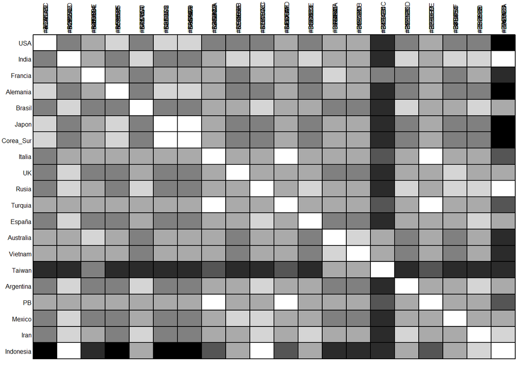

```r
# Generar una paleta de colores de grises válidos
grises <- gray.colors(n = 100)

# Usar la paleta de colores en la función de visualización (reemplaza temp por tus datos)
library(RColorBrewer)
library(plotrix)

table.paint(temp, cleg = 0, clabel.row = 0.5, clabel.col = 0.5, col = grises)
```

12. Creación del árbol con el paquete ape:

```r
virus_filogenetico <- njs(matriz_distancia)
class(virus_filogenetico)
```

```
## [1] "phylo"
```

13. Plot del árbol:

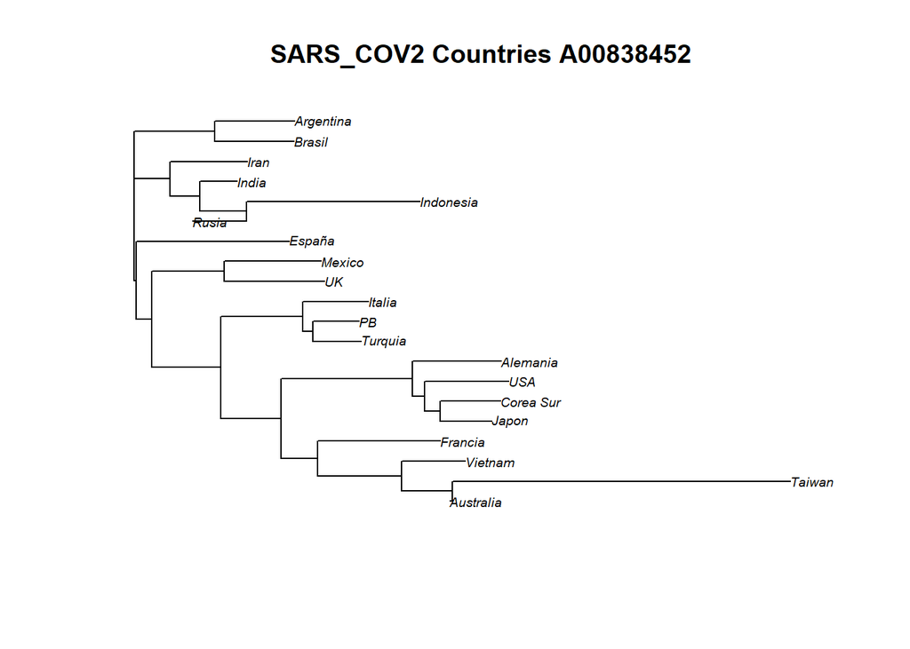

```r
virus_plot_filogenetico <- ladderize(virus_filogenetico)
plot(virus_plot_filogenetico, cex = 0.6)
title("SARS_COV2 Countries A00838452")
```

14. Plot utilizando ggtree que es parte de ggplot:

[output not shown]